# Single case experimental design & meta analysis using the SCED package

Vignette

Ian Hussey

```r
# dependencies
library(SCED)
library(knitr)
library(kableExtra)
library(tidyverse)

# dependencies required by SCED
library(broom)
library(coin)
library(survival)
library(effsize)
library(bootES)
library(boot)
library(stringr)
library(timesavers)  # from github/ianhussey

# disable scientific notation
options(scipen = 999)
```

# Participant level analyses

Using the package’s built in dataset. A copy of this dataset is saved to the vignette folder, for those that want to know how data must be formatted to be analysed by this package.

Robust hypothesis testing via permuted *p* values, and 95% CIs on robust unstandardized (median change) and standardized effect sizes (Non-overlap all pairs/Ruscio’s A and Hedge’s *g*).

Baseline trends also identified using standardized beta regression coefficients.

```r
# save copy
write_csv(simulated_data, "example_data.csv")

# analyse
results <- sced_analysis(data = simulated_data)

results %>%
  kable() %>%
  kable_styling(bootstrap_options = c("striped", "hover", "condensed"), full_width = FALSE)
```

| Participant | Baseline trend | Intervention trend | p | median_difference | ruscios_A | ruscios_A_se | ruscios_A_ci_lwr | ruscios_A_ci_upr | hedges_g | hedges_g_se | hedges_g_ci_lwr | hedges_g_ci_upr |
| --- | --- | --- | --- | --- | --- | --- | --- | --- | --- | --- | --- | --- |
| 1 | -0.57 | 0.32 | = .0106 | 1.81 | 0.800 | 0.103 | 0.490 | 0.940 | 1.036 | 0.577 | -0.063 | 2.058 |
| 2 | 0.27 | 0.18 | < .0001 | 2.42 | 0.885 | 0.087 | 0.455 | 0.985 | 1.893 | 0.728 | 0.641 | 3.201 |
| 3 | 0.27 | 0.35 | < .0001 | 1.59 | 0.916 | 0.047 | 0.760 | 0.973 | 1.711 | 0.359 | 0.988 | 2.347 |
| 4 | 0.21 | -0.08 | = .0026 | 1.67 | 0.838 | 0.074 | 0.627 | 0.947 | 1.160 | 0.501 | 0.174 | 2.072 |
| 5 | 0.16 | 0.07 | < .0001 | 2.75 | 0.960 | 0.033 | 0.815 | 0.996 | 2.169 | 0.431 | 1.366 | 2.934 |
| 6 | 0.01 | -0.42 | < .0001 | 2.15 | 0.945 | 0.039 | 0.800 | 0.990 | 2.169 | 0.560 | 1.232 | 3.149 |

## Plot

SCED plots with raw data, intervention point (vertical dotted line), median score within phases (horizontal dashed lines), and trends (regression lines).

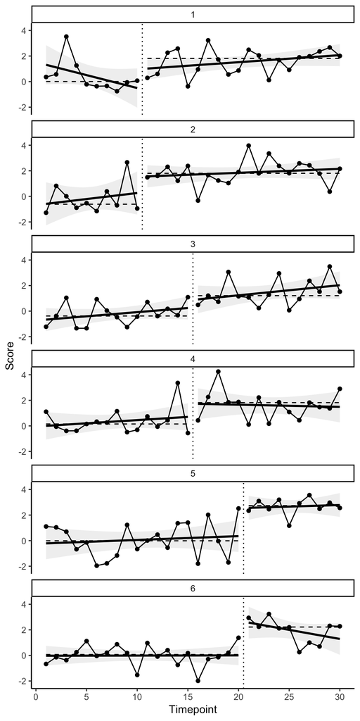

```r
sced_plot(data = simulated_data)
```

# Meta analysis

Random effects meta analysis of standardized effect sizes across participants, plotting a standard forest plot. Includes meta analysed effect sizes, 95% confidence intervals (estimates of true effect sizes), 95% credibility intervals (estimates of effect sizes likely to be observed in future participants), and heterogenity metrics (differences in effect between participants).

You can optionally exclude participants from the meta analysis using the `baseline_trend_exclusion_criterion` parameter. You can change which effect size is meta analysed using the `effect_size` parameter.

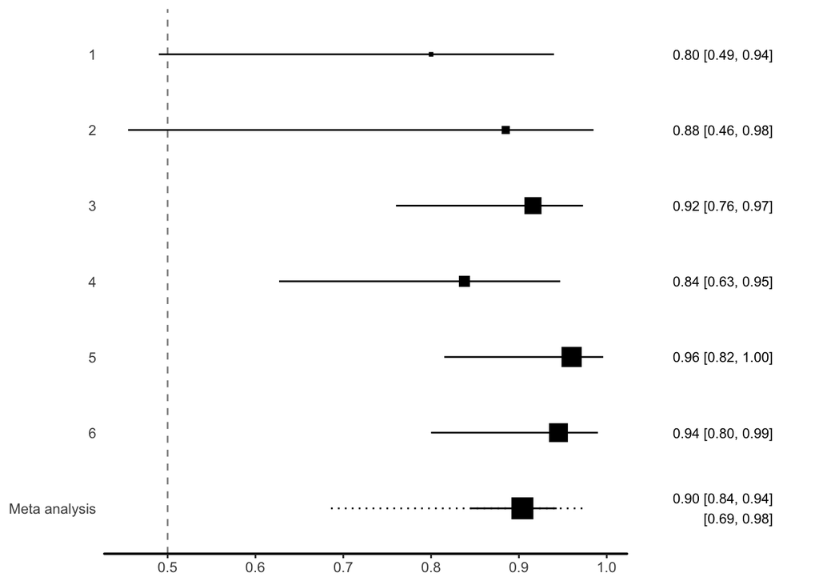

```r
# meta analysis
meta_analysis <- sced_meta_analysis(results = results, effect_size = "ruscios_A")

# forest plot
forest_plot(meta_analysis, effect_size = "ruscios_A")
```

- Meta analysis: N = 6, unstandardized effect size (median median-difference) = 1.98, Ruscio’s A = 0.904, 95% CI [0.845, 0.943], 95% CR [0.686, 0.976], Generalized OR = 9.46, 95% CI [5.44, 16.44], 95% CR [2.19, 40.89], p < .0001
- Heterogeneity tests: Q(df = 5) = NA, p NA, tau^2 = 0.48, I^2 = NA, H^2 = NA

# Simulate SCED data

In order to learn to use the package without using the data you wish to ultimately analyse (which can be a source of unintentional p hacking), SCED data can easily be simulated using the `simulate_data` function. The number of participants, timepoints at A and B, and true effect size can be set to arbitrary values.

```r
# simulate data
data <- simulate_data(participants = 2,     # two participants
                      timepoints_a = 10,    # 10 timepoints pre
                      timepoints_b = 10,    # 10 post intervention
                      cohens_d     = 2) %>% # Cohen's d = 2
  mutate(Participant = paste("Participant", Participant))
```